# 第9回 全微分と 2 変数の最大・最小

経済学基礎数学II

第9回

全微分と 2 変数の最大・最小

斜めに 1 歩、そして頂点を探す

経済学基礎数学II

第9回 — Topic01

全微分

斜めに 1 歩、進んだら

## 第9回の道のり

1

全微分の式

演習 1-1 全微分の式と値

2

等高線の傾き

演習 2-1 等高線の傾きの値

3

1 階の条件

演習 3-1 候補と値

4

山か谷か峠か

演習 4-1 $D$ で判定

演習 4-2 STEP $4$ つを通す

いまココ — $x$ も $y$ も、いっぺんに動かしてみる

## 前回の振り返り

前回のポイント — 多変数関数の偏微分

Q: 山の斜面で、傾きをどう測ったか

- **偏微分**: 片方の文字を定数だと思って、もう片方だけで微分した
- **$x$ 方向と $y$ 方向**: 同じ場所でも、向きによって下り方が違った
- **峠**: $x$ 方向は上りで、$y$ 方向は下りという場所もあった

測ったのは、$x$ 方向と $y$ 方向の $2$ つだけ

## 偏微分の復習

丘 $f(x, y) = 10 - x^2 - y^2$（前の回の丘。この回は $f$ で書く）  
相手の文字を定数だと思って、残りの $1$ 文字で微分する

$y$ を定数と思って $x$ で偏微分

$\dfrac{\partial f}{\partial x} = -2x$

$\Downarrow$$(1, 2)$ を入れる

$\dfrac{\partial f}{\partial x}(1, 2) = -2 \cdot 1 = -2$

$x$ を定数と思って $y$ で偏微分

$\dfrac{\partial f}{\partial y} = -2y$

$\Downarrow$同じ点を入れる

$\dfrac{\partial f}{\partial y}(1, 2) = -2 \cdot 2 = -4$

かっこの中は、前が $x$、後ろが $y$. 偏微分が先、点を入れるのは後

## 点 $(1, 2)$ での $2$ つの傾き

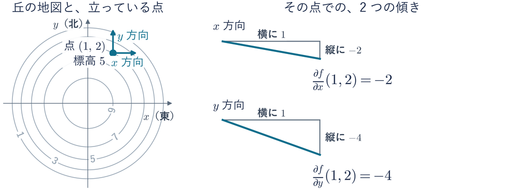

この点での傾きは $x$ 方向 $-2$, $y$ 方向 $-4$. どちらも下り

## このトピックで学ぶこと

- **いまの道具**：偏微分で、  
  $x$ だけ・$y$ だけ動かしたときの傾きが出せる
- **足りない所**：ふだんは $2$ つが同時に動く。時給が上がった月に、  
  シフトが減ることもある
- **知りたいこと**：$2$ つが同時に少し動いたら、  
  全体はどれだけ変わるか
- **新しい道具**：全微分。新しい記号は $dx$, $dy$, $dz$ の $3$ つ
- **偏微分と全微分**：偏微分は、向きを $x$ か $y$ に決めた傾き  
  全微分は、$dx$, $dy$ で決めた斜めの $1$ 歩での、高さの変化

まず丘で考え、そのあと給料で同じ手順を通す

## $2$ つの向きへ $0.1$ ずつの見積もり

丘の点 $(1, 2)$（標高 $5$）から、$x$ 方向へ $0.1$ と同時に、$y$ 方向へも $0.1$ 進む

$\frac{\partial f}{\partial x}(1, 2) \times 0.1$

$= (-2) \times 0.1 = -0.2$

$x$ 方向の分（傾き × 進んだ分）

$\frac{\partial f}{\partial y}(1, 2) \times 0.1$

$= (-4) \times 0.1 = -0.4$

$y$ 方向の分（傾き × 進んだ分）

$-0.2 + (-0.4)$

$= -0.6$

$2$ つの分を足す

見積もり $-0.6$ 向きごとの分を出して、足しただけ

## 斜めの $1$ 歩の分け方

[figure not shown]

$dx$：$x$ 方向へ進んだ**ほんの少し** $dy$：$y$ 方向へ進んだ**ほんの少し**  
この進んだ量を、これから**歩幅**と呼ぶ

## 積み上げた先と実際の標高

[figure not shown]

実際は $f(1.1, 2.1) = 10 - 1.21 - 4.41 = 4.38$  
実際の変化は $4.38 - 5 = -0.62$. 見積もり $-0.6$ に近い

## 歩幅とずれの表

| $x$ 方向へ $dx$ | $y$ 方向へ $dy$ | 見積もり | 実際 | ずれ |
| --- | --- | --- | --- | --- |
| $1$ | $1$ | $-6$ | $-8$ | $2$ |
| $0.1$ | $0.1$ | $-0.6$ | $-0.62$ | $0.02$ |
| $0.01$ | $0.01$ | $-0.06$ | $-0.0602$ | $0.0002$ |

歩幅が $\frac{1}{10}$ になると、ずれは $\frac{1}{100}$ ほどに縮む

## 平らな板の上の足し算

[figure not shown]

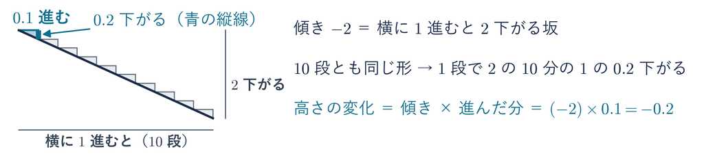

## 全微分の定義

定義 — 全微分

$$dz = \underbrace{\color{#0f6e8c}{\frac{\partial f}{\partial x}\,dx}}_{\color{#0f6e8c}{\text{青の縦線}}} + \underbrace{\color{#c2410c}{\frac{\partial f}{\partial y}\,dy}}_{\color{#c2410c}{\text{オレンジの縦線}}}$$

- **$dx$, $dy$**：$x$ 方向・$y$ 方向へ進んだ**ほんの少し**の量
- **$dz$**：高さ $z = f(x, y)$ の変化の**見積もり**  
  割らずに書くので分母が無い。⚠ 実際の変化そのものではない
- **変数が $1$ つなら**：$dz = f'(x)\,dx$ を $dx$ で割ると傾き $f'(x)$

読み下すと「傾き × 進んだ分」を $x$, $y$ で足したもの

## ◼ 全微分の求め方 STEP $4$ つ

$dz$ は、いつもこの順で出す

1. **偏微分を $2$ つ作る**（$x$ で $1$ 回、$y$ で $1$ 回偏微分）
2. **全微分の式に入れる**
3. **点を入れて、$2$ つの係数（$dx$, $dy$ の前の数）を数にする**
4. **歩幅 $dx$, $dy$ を入れて $dz$ を出す**

計算ドリル9 のブロック $1$ も、この番号どおり

## 例題 $f(x, y) = x^2 y$ の全微分

点 $(3, 2)$ から $dx = 0.1$, $dy = -0.1$ 進む

STEP 1

$\frac{\partial f}{\partial x} = 2xy$, $\frac{\partial f}{\partial y} = x^2$

相手を定数と思って偏微分

STEP 2

$dz = 2xy\,dx + x^2\,dy$

全微分の式に入れる

STEP 3

$\frac{\partial f}{\partial x}(3, 2) = 2 \cdot 3 \cdot 2 = 12$

点を入れる。前が $x$、後ろが $y$

$\frac{\partial f}{\partial y}(3, 2) = 3^2 = 9$

STEP 4

$dz = 12 \times 0.1 + 9 \times (-0.1)$

歩幅を入れる

$\phantom{dz} = 1.2 - 0.9 = 0.3$

$dy = -0.1$ は「$y$ の負の向きへ $0.1$」。$x$ 方向へ進みながら $y$ は減る歩き方

## 例題の見積もりと実際

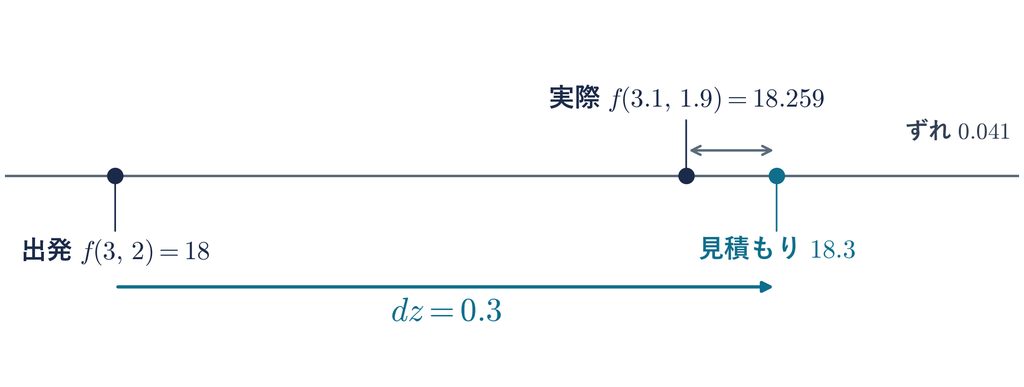

$f(3, 2) = 18$ $f(3.1, 1.9) = 3.1^2 \times 1.9 = 9.61 \times 1.9 = 18.259$  
実際の変化は $18.259 - 18 = 0.259$

## 時給と時間で決まる給料

今度は給料で、同じ STEP を通す $W(w, h) = wh$  
$w$：時給（円） $h$：はたらく時間（時間） $W$：給料（円）

[figure not shown]

時給が $50$ 円上がり、シフトが $2$ 時間減る。給料は増える？減る？

## 給料の $2$ つの偏微分

$h$ を定数と思って $w$ で偏微分

$\dfrac{\partial W}{\partial w} = h$

$\Downarrow$点を入れる

$\dfrac{\partial W}{\partial w}(1200, 40) = 40$

$w$ を定数と思って $h$ で偏微分

$\dfrac{\partial W}{\partial h} = w$

$\Downarrow$同じ点を入れる

$\dfrac{\partial W}{\partial h}(1200, 40) = 1200$

- **$40$**：時給が $1$ 円上がると、給料は $40$ 円増える（$40$ 時間ぶん）
- **$1200$**：シフトが $1$ 時間増えると、給料は $1200$ 円増える（時給ぶん）

## 給料の変化の見積もり

STEP 1 は前のページ。歩幅は $dw = 50$, $dh = -2$

STEP 2

$dW = h\,dw + w\,dh$

全微分の式に入れる

STEP 3

$dW = 40\,dw + 1200\,dh$

点 $(1200, 40)$ を入れる

STEP 4

$dW = 40 \times 50 + 1200 \times (-2)$

歩幅を入れる

$\phantom{dW} = 2000 - 2400 = -400$

時給の分で $2000$ 円増え、  
シフトの分で $2400$ 円減る。見積もりは $400$ 円の減り

## 長方形で見る見積もりと実際

[figure not shown]

実際は $1250 \times 38 - 48000 = -500$ 円。見積もり $-400$ 円とのずれは $100$ 円  
ずれは右上の角 $50 \times 2 = 100$ 円の分。動きが小さいほど、角は小さい

## 演習 1-1 全微分の式と値

演習 1-1 ／ 計算ドリル9

ブロック $1$ の全問。全微分 $dz$ の式と値を出す

- **復習 A** $f(x, y) = 3x^2 + 4xy$ を、$x$ と $y$ でそれぞれ偏微分
1. $f(x, y) = 3x^2 + 2y^2$ で、点 $(1, 2)$ から $dx = 0.1$, $dy = 0.1$ のときの $dz$ の式と値
2. $f(x, y) = 2x^3 + 5y^2$ の $dz$ を式で
3. 給料 $W = wh$. 時給 $1000$ 円で $30$ 時間から $dw = 100$, $dh = -2$ のときの $dW$  
   実際の変化（動いた後の給料 − いまの給料）とも見くらべる

⏸ PAUSE 動画を止めて、ノートに解く。問 $1$ が解けたら再生に戻る  
問 $2$・$3$ と復習 A は、そのあと解いて配った答えで確かめる

## 演習 1-1 の答え — 問 $1$

**問 $1$** $f(x, y) = 3x^2 + 2y^2$ 点 $(1, 2)$, $dx = 0.1$, $dy = 0.1$

STEP 1

$\frac{\partial f}{\partial x} = 6x$, $\frac{\partial f}{\partial y} = 4y$

STEP 2

$dz = 6x\,dx + 4y\,dy$

STEP 3

$\frac{\partial f}{\partial x}(1, 2) = 6 \cdot 1 = 6$

$\frac{\partial f}{\partial y}(1, 2) = 4 \cdot 2 = 8$

STEP 4

$dz = 6 \times 0.1 + 8 \times 0.1 = 0.6 + 0.8 = 1.4$

こたえ $dz = 1.4$ $x$ 方向の分 $0.6$ と $y$ 方向の分 $0.8$ を、分けて出してから足す

## まとめ

- 斜めの $1$ 歩は、$x$ 方向の分と $y$ 方向の分に分けて足す
- 全微分は $dz = \frac{\partial f}{\partial x}dx + \frac{\partial f}{\partial y}dy$. 求め方は STEP $4$ つ
- $dz$ は見積もり。歩幅が小さいほど、実際とのずれが小さい
- 給料でも同じ。時給 $+50$ 円・シフト $-2$ 時間で、  
  見積もりは $400$ 円の減り

板なら足せる。  
まだ答えていない問い：曲がった丘でも、板で見積もってよいのか  
給料を変えないなら、シフトを何時間まで減らせるか。  
これを次のトピックで見る

経済学基礎数学II

第9回 — Topic02

接平面と等高線の傾き

平らな板を当てている

## 第9回の道のり

1

全微分の式

演習 1-1 全微分の式と値

2

等高線の傾き

演習 2-1 等高線の傾きの値

3

1 階の条件

演習 3-1 候補と値

4

山か谷か峠か

演習 4-1 $D$ で判定

演習 4-2 STEP $4$ つを通す

いまココ — $2$ つの傾きを、組み合わせる

## このトピックで学ぶこと

- **いまの道具**：全微分で、時給とシフトが同時に動いたときの給料の  
  変化を見積もれる（$-400$ 円）
- **足りない所**：時給が上がった月に、  
  給料を変えずにシフトを何時間まで減らせるか、まだ出せない。  
  曲がった丘でも板で見積もってよい理由も、まだ見ていない
- **知りたいこと**：高さ（給料）を変えずに動く向き
- **新しい道具**：接平面（平らな板）と、等高線の傾き

丘で平らな板を作り、給料の交換で $dW = 0$ とおく。  
最後に丘の等高線で絵にする

## 丘の斜面の立っている点

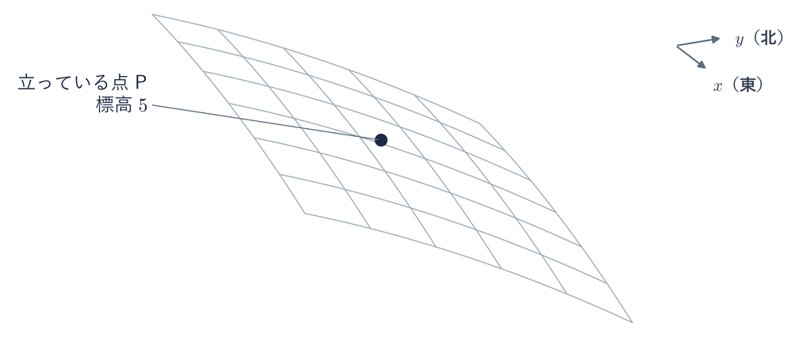

丘 $f(x, y) = 10 - x^2 - y^2$ の点 $(1, 2)$ の標高は $f(1, 2) = 5$  
ここから、ほんの少しだけ動く

## 分かっている $2$ つの傾き

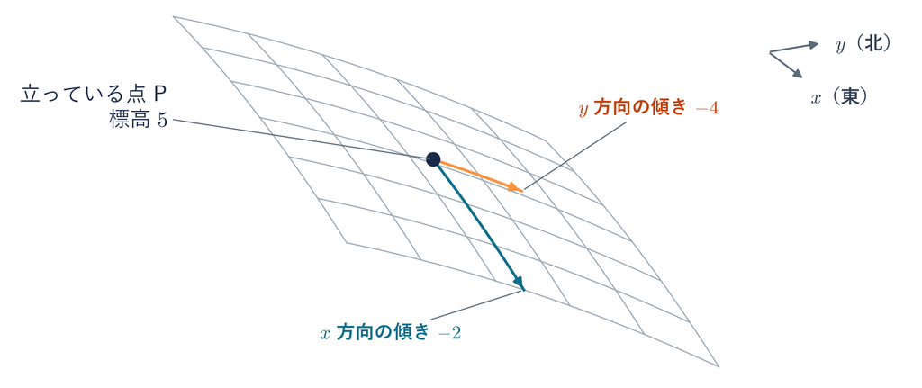

$\frac{\partial f}{\partial x}(1, 2) = -2$：この点での $x$ 方向の傾き  
$\frac{\partial f}{\partial y}(1, 2) = -4$：この点での $y$ 方向の傾き

## $x$ 方向へ $dx$ の移動

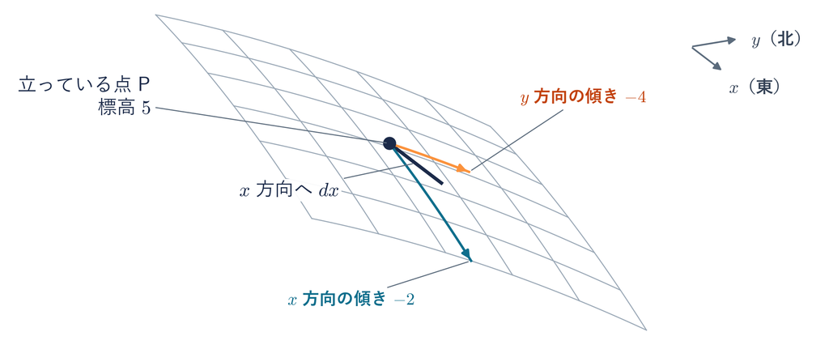

地面の上を、$x$ 方向へほんの少し。まだ高さの話はしていない

## $x$ 方向の分の下がり

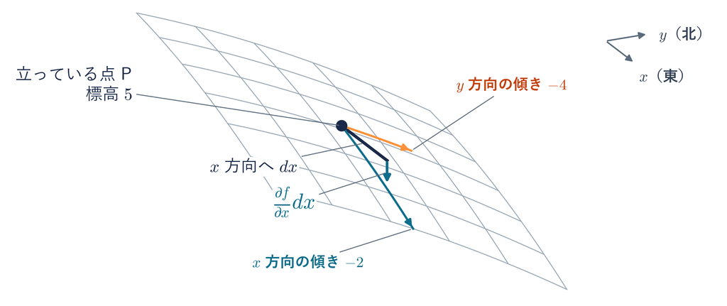

高さの変化は $x$ 方向の傾き × 進んだ分。式では $\frac{\partial f}{\partial x}dx$（負なので下がる）

## $y$ 方向へ $dy$ の移動

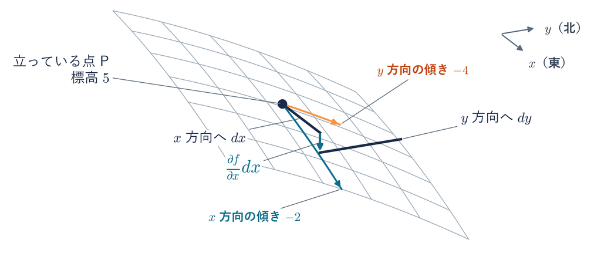

$x$ 方向へ進んだ場所から、そのまま $y$ 方向へ。これも地面の上の話

## $y$ 方向の分の下がり

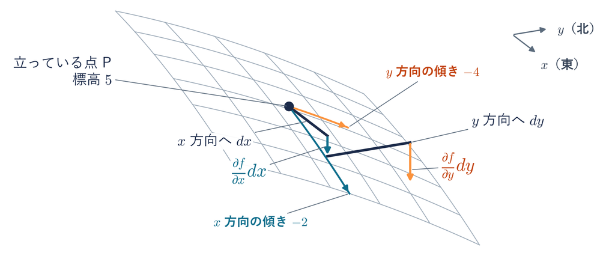

高さの変化は $y$ 方向の傾き × 進んだ分。式では $\frac{\partial f}{\partial y}dy$（負なので下がる）

## 積み上げた先の $dz$

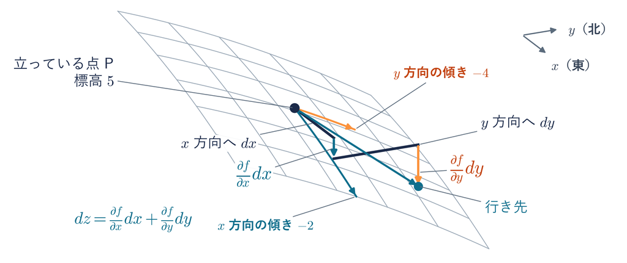

$2$ つを積み上げた高さが $dz = \frac{\partial f}{\partial x}dx + \frac{\partial f}{\partial y}dy$  
**行き先**：歩いた先の地面の真上で、高さが $5 + dz$ の点

## 別の向きの行き先

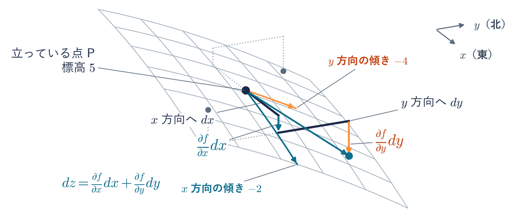

斜めのどの向きでも同じ手。**あらゆる向きの行き先を集めると？**  
予想 ① ばらばらの点 ② $1$ 枚の平らな面 ③ 丘と同じ曲面

## あらゆる向きの行き先

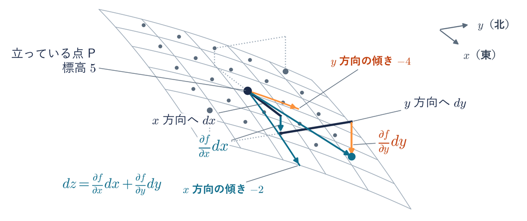

行き先の点が、$1$ つの面の上にきれいに並ぶ

## 行き先が作る平らな板

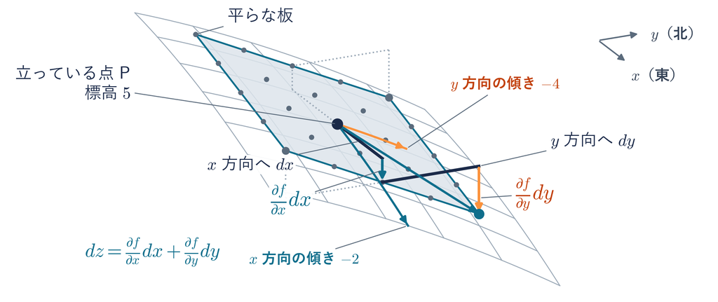

これが**接平面**。全微分の式は、この板の上を歩いたときの高さの変化

## デモ：板を回して、段を足して見る

数の話

丘 $h = 10 - x^2 - y^2$ の点 $(1, 2)$・標高 $5$  
板の上で $dz = -2\,dx - 4\,dy$

- **何を見るか**：$2$ つの段が、板の上で縦に積み上がること
- **図の意味**：青緑は $x$ の分、橙は $y$ の分。白丸は丘の上
- **操作**：タブ $3$ つと板・歩幅。ドラッグでも回る

ミッション 歩幅 $0.3$ で、板と丘のすき間が見える向き探し

※ 次のスライドへ進むときは、デモの枠の外を一度クリックしてから ← → キーを押す

[interactive chart not shown]

## 板なら足せる理由

用語

**接平面**：曲面の $1$ 点に当てた平らな板  
（$1$ 変数の接線の、$2$ 変数版）

- **斜面は傾きが変わる**：$x$ 方向の傾き $\frac{\partial f}{\partial x} = -2x$ は、  
  $x = 1$ で $-2$, $x = 1.5$ で $-3$
- **板はどこでも同じ傾き**：$x$ 方向 $-2$, $y$ 方向 $-4$ のまま。  
  だから傾き × 進んだ分を足せる
- **全微分 $dz$**：この板の上を歩いたときの高さの変化
- **近くなら斜面は板とほぼ同じ**：だから斜面でも、足した値は見積もり

## 板と斜面の $2$ つの断面

[figure not shown]

$y = 2$ で切ると $f(x, 2) = 6 - x^2$（接線の傾き $-2$）  
$x = 1$ で切ると $f(1, y) = 9 - y^2$（接線の傾き $-4$）

## 給料を変えない時給とシフト

前のトピック：時給 $+50$ 円・シフト $-2$ 時間で  
$dW = -400$ 円と見積もった  
給料 $W(w, h) = wh$ 図は時給 $w$ が横、時間 $h$ が縦

[figure not shown]

今度は逆。給料 $48000$ 円を変えずに、時給とシフトをどう交換できるか

## 時給の分とシフトの分の打ち消し

給料を変えないので $dW = 0$ とおく $h\,dw + w\,dh = 0$

[figure not shown]

## 交換の比率の一般の式

$dw$：時給の変化（円） $dh$：シフトの変化（時間） $dW = 0$：給料を変えない  
$\frac{dh}{dw}$：時給 $1$ 円あたりのシフトの変化 ＝ **交換の比率**

**証明**

$h\,dw + w\,dh = 0$

$\Longrightarrow$  
左の項を右へ

$w\,dh = -h\,dw$

$\Longrightarrow$  
$w$ と $dw$ で割る

$\dfrac{dh}{dw} = -\dfrac{h}{w}$

交換の比率

$$\frac{dh}{dw} = -\frac{h}{w}$$

## 点 $(1200, 40)$ での交換の比率

今回の点：時給 $w = 1200$ 円、シフト $h = 40$ 時間

**今回 $(1200, 40)$**

$40\,dw + 1200\,dh = 0$

$\Downarrow$左の項を右へ移す

$1200\,dh = -40\,dw$

$\Downarrow$$1200$ と $dw$ で割る

$\dfrac{dh}{dw} = -\dfrac{40}{1200} = -\dfrac{1}{30}$

$-\frac{1}{30}$：時給 $1$ 円上がるごとに、シフトは約 $2$ 分減る（等高線の傾き）

## 給料を保つシフトの見積もりと実際

比率 $-\frac{1}{30}$ は正確。$50$ 円ぶんに掛けた $dh = -\frac{1}{30} \times 50 = -\frac{5}{3}$ 時間  
（$1$ 時間 $40$ 分）は見積もり

[figure not shown]

実際に減らせるのは $1.6$ 時間（$1$ 時間 $36$ 分）  
見積もりは $4$ 分の減らしすぎ。等高線が曲がっている分

## $dz = 0$ からの式変形

給料と同じ手順を丘で。標高を変えないなら $dz = 0$ とおく

$\dfrac{\partial f}{\partial x}\,dx + \dfrac{\partial f}{\partial y}\,dy = 0$

$\Longrightarrow$  
左の項を右へ

$\dfrac{\partial f}{\partial y}\,dy = -\dfrac{\partial f}{\partial x}\,dx$

$\Big\Downarrow$ $\frac{\partial f}{\partial y}$ と $dx$ で割る

計算の結果 $\dfrac{dy}{dx} = -\dfrac{\partial f / \partial x}{\partial f / \partial y}$

## 等高線の傾きの公式

公式

$$\frac{dy}{dx} = -\frac{\partial f / \partial x}{\partial f / \partial y}$$

- **等高線の傾き**：標高を変えずに進む向きの傾き。等高線の接線の傾き
- **形**：上が $x$ の偏微分、下が $y$ の偏微分。頭のマイナスまでが公式
- **言葉にすると**：$x$ 方向の傾きを $y$ 方向の傾きで割って、符号を裏返す
- **値の読み方**：$x$ 方向へほんの少し進むとき、$y$ 方向へその $\frac{dy}{dx}$ 倍進めば、  
  標高の変化の見積もりは $0$
- **使えない場合**：$\frac{\partial f}{\partial y} = 0$ の点（割り算ができない）

## 例題 丘の点 $(1, 2)$ を $dz = 0$ から解く

**例題** 丘の点 $(1, 2)$ で、$dz = 0$ とおく手順を数でたどる  
この点の傾き：$x$ 方向 $-2$, $y$ 方向 $-4$

$-2\,dx - 4\,dy = 0$

$\Longrightarrow$  
左の項を右へ

$-4\,dy = 2\,dx$

$\Longrightarrow$  
$-4$ と $dx$ で割る

$\dfrac{dy}{dx} = \dfrac{2}{-4} = -\dfrac{1}{2}$

公式に入れても：$\dfrac{dy}{dx} = -\dfrac{\partial f / \partial x}{\partial f / \partial y} = -\dfrac{-2}{-4} = -\dfrac{1}{2}$. 同じ値になる

地図の上で横に $dx$、縦に $dy$ 進む  
$\frac{dy}{dx}$ はその向きの傾き（この縦は高さではない）

## ◼ 等高線の傾きの求め方 STEP $4$ つ

標高を変えずに歩く向きは、いつもこの順で出す

1. **偏微分を $2$ つ作る**（$x$ で $1$ 回、$y$ で $1$ 回偏微分）
2. **上を $x$ の偏微分、下を $y$ の偏微分にして分数にする**
3. **頭にマイナスを付ける**
4. **点を入れて数にし、「$x$ 方向に $1$ なら、$y$ 方向へどれだけ」と言葉にする**

計算ドリル9 のブロック $2$ も、この番号どおり

## 例題 丘の等高線の傾き

丘 $f(x, y) = 10 - x^2 - y^2$ の点 $(1, 2)$ での等高線の傾き

STEP 1

$\frac{\partial f}{\partial x} = -2x$, $\frac{\partial f}{\partial y} = -2y$

相手を定数と思って偏微分

STEP 2

$\frac{-2x}{-2y}$

上が $x$ の偏微分、下が $y$ の偏微分

STEP 3

$\frac{dy}{dx} = -\frac{-2x}{-2y} = -\frac{x}{y}$

頭にマイナス。$-2$ を約分

STEP 4

$\frac{dy}{dx} = -\frac{1}{2}$

点 $(1, 2)$：$x = 1$, $y = 2$ を入れる

STEP 3 までは $x$, $y$ が残る式。点を入れて数にするのは STEP 4

## 点 $(1, 2)$ を通る等高線の接線

[figure not shown]

$\frac{dy}{dx} = -\frac{1}{2}$：割合は「$x$ 方向に $1$ なら $y$ の負の向きへ $\frac{1}{2}$」  
点線は、標高 $5$ の等高線（円）にちょうど接する

## 演習 $2$-$1$ 等高線の傾きの値

演習 2-1 ／ 計算ドリル9

ブロック $2$ の全問。点での値を出して言葉にする（STEP 4 まで）

- **復習 C** $6x + 3y = 0$ を $y = \cdots$ の形に直す。$\frac{4x}{6y}$ を約分する
1. $f(x, y) = 2x^2 + y^2$, 点 $(1, 4)$ （言い方「$x$ 方向に $1$ 進むなら…」）
2. $f(x, y) = x^2 + xy$, 点 $(1, 2)$
3. 給料 $W = wh$. 時給 $1000$ 円で $30$ 時間  
   (1) 給料の等高線の傾き $\frac{dh}{dw}$ を式で (2) いまの点での値  
   (3) 時給が $10$ 円上がるなら、給料を変えずにシフトをおよそ何時間減らせるか

⏸ PAUSE 動画を止めて、ノートに解く。問 $1$ が解けたら、いったん再生に戻る  
問 $2$・$3$ と復習 C は、そのあと解いて配った答えで確かめる

## 演習 2-1 の答え — 問 $1$

**問 $1$** $f(x, y) = 2x^2 + y^2$ 点 $(1, 4)$

STEP 1

$\frac{\partial f}{\partial x} = 4x$, $\frac{\partial f}{\partial y} = 2y$

STEP 2

$\frac{4x}{2y}$

STEP 3

$\frac{dy}{dx} = -\frac{4x}{2y} = -\frac{2x}{y}$

約分する

STEP 4

$\frac{dy}{dx} = -\frac{2 \cdot 1}{4} = -\frac{1}{2}$

点 $(1, 4)$：$x = 1$, $y = 4$ を入れる

こたえ $-\frac{1}{2}$ 割合は  
「$x$ 方向に $1$ なら $y$ の負の向きへ $0.5$」。ほんの少し進む向きの話

## まとめ

- 全微分は、点に当てた**平らな板**（接平面）  
  の上を歩いたときの高さの変化。  
  板の傾きはどこでも同じなので、足してよい
- $dz = 0$ とおくと、等高線の傾き $\frac{dy}{dx} = -\frac{\partial f / \partial x}{\partial f / \partial y}$. 求め方は STEP $4$ つ
- 給料を変えないなら $dW = 0$：時給 $1$ 円あたりシフトは $-\frac{1}{30}$ 時間  
  （約 $2$ 分）。$+50$ 円で見積もり $\frac{5}{3}$ 時間の減り（実際は $1.6$ 時間）
- 丘の $(1, 2)$ では $-\frac{1}{2}$

まだ答えていない問い：傾きが $2$ つとも $0$ の点では、  
この式で向きが決まらない。そんな点はどこにあるか  
これを次のトピックで見る

経済学基礎数学II

第9回 — Topic03

1 階の条件

頂点に立ったときの足もと

## 第9回の道のり

1

全微分の式

演習 1-1 全微分の式と値

2

等高線の傾き

演習 2-1 等高線の傾きの値

3

1 階の条件

演習 3-1 候補と値

4

山か谷か峠か

演習 4-1 $D$ で判定

演習 4-2 STEP $4$ つを通す

いまココ — $2$ つの傾きを、$0$ とおく

## このトピックで学ぶこと

- **いまの道具**：$2$ つの傾きを足す（全微分）・比にする（等高線の傾き）
- **足りない所**：模擬店で $2$ 品を売るとき、  
  利潤がいちばん大きくなる本数と袋数を決めたい。  
  $1$ 品なら春に $f'(x) = 0$ で探せたが、$2$ つの数を同時に決める道具は無い
- **知りたいこと**：山頂や谷底では $2$ つの傾きはどうなっているか  
  （前のトピックで残した「$2$ つとも $0$ の点」）
- **新しい道具**：$1$ 階の条件と、それを満たす候補

**頂点**＝山頂か谷底。放物線の頂点が上にも下にもあるのと同じ。峠は頂点ではない

まず丘で山頂の足もとを見て、そのあと模擬店で同じ手順を通す

## 山頂と斜面の足もと

[figure not shown]

山頂 $(0, 0)$ では $x$ 方向も $y$ 方向も傾き $0$  
斜面 $(1, 2)$ では、どちらも下り。反対の向きへ戻れば上れる

## $4$ か所の $2$ つの傾き

[figure not shown]

**片方だけ $0$ では足りない** $2$ つとも $0$ なのは山頂 $(0, 0)$ だけ

## 頂点で $2$ つの傾きが $0$ になる理由

前のトピックの見積もり $dz = \frac{\partial f}{\partial x}\,dx + \frac{\partial f}{\partial y}\,dy$ で確かめる

1. **山頂では、どの向きに $1$ 歩出ても上れない**（谷底では、下れない）
2. **$dz \neq 0$ の $1$ 歩があれば、その向きか逆向きで上れる**  
   （$1$ 歩が十分小さいとき。谷底なら下れる）
3. **だから頂点では、どの $1$ 歩でも $dz = 0$**
4. **$dx$, $dy$ にどんな数を入れても $\frac{\partial f}{\partial x}\,dx + \frac{\partial f}{\partial y}\,dy = 0$**  
   **そうなるのは、$2$ つの傾きがどちらも $0$ のときだけ**

頂点では $\frac{\partial f}{\partial x} = 0$ かつ $\frac{\partial f}{\partial y} = 0$

## $1$ 階の条件の定義

範囲の端ではない頂点では、$x$ 方向にも $y$ 方向にも傾いていない

定義 — $1$ 階の条件

$$\frac{\partial f}{\partial x} = 0, \qquad \frac{\partial f}{\partial y} = 0$$

- **$1$ 階**：$1$ 回だけ偏微分した傾きを使う、という意味
- **候補**：この $2$ 本を同時に満たす点
- **端**：売る数の $0$ のような、それ以上減らせない所（別に考える）

## 峠の原点の $2$ つの傾き

[figure not shown]

峠 $z = x^2 - y^2$ の原点でも、$\frac{\partial z}{\partial x} = 2x$ と $\frac{\partial z}{\partial y} = -2y$ はどちらも $0$

## ★ 候補と頂点の違い

**足もとが平らなだけでは、頂点とは限らない**

- **言えること**：範囲の端ではない頂点なら、$2$ つの傾きは必ず $0$
- **言えないこと**：$2$ つの傾きが $0$ でも、頂点とは限らない（峠も $0$）。  
  頂点でも、山頂か谷底かは分からない
- **だから二段構え**：まず候補を全部見つけ、  
  そのあと山頂か谷底か峠かを選り分ける

このトピックは一段目の候補まで。選り分け方は次のトピックで見る

## ◼ 候補の求め方 STEP $4$ つ

値は、その点の高さ（お店なら利潤）。候補と値は、いつもこの順で出す

1. **$x$ で偏微分する**
2. **$y$ で偏微分する**
3. **両方 $= 0$ とおく（これが $1$ 階の条件）。連立を解く**
4. **出てきた点での $f$ の値を出す**

計算ドリル9 のブロック $3$ も、この番号どおり

## 例題 候補とその点での値

$f(x, y) = x^2 + y^2 - 6x + 2y + 5$ の候補と、そこでの $f$ の値

STEP 1

$\frac{\partial f}{\partial x} = 2x - 6$

$x$ で偏微分

STEP 2

$\frac{\partial f}{\partial y} = 2y + 2$

$y$ で偏微分

STEP 3

$2x - 6 = 0$, $2y + 2 = 0 \;\Rightarrow\; x = 3$, $y = -1$

別々に解ける

STEP 4

$f(3, -1) = 3^2 + (-1)^2 - 6 \cdot 3 + 2 \cdot (-1) + 5$

点を入れる

$\phantom{f(3, -1)} = 9 + 1 - 18 - 2 + 5 = -5$

候補は $(3, -1)$ そこでの値は $-5$

## 候補が $2$ つ出る関数

[figure not shown]

$3x^2 - 3 = 0$ → $3x^2 = 3$ → $x^2 = 1$ から $x = 1$ と $x = -1$  
$2y = 0$ から $y = 0$. 候補は $(1, 0)$ と $(-1, 0)$ の $2$ つ。出たものは全部残す

## 模擬店の $2$ 品の利潤

- **売る物**：フランクフルト $x$ 本（$1$ 本 $70$ 円）と、  
  ポップコーン $y$ 袋（$1$ 袋 $50$ 円）
- **費用**：$x^2 + xy + y^2$ 円。$x^2$ と $y^2$ は、  
  たくさん作るほど $1$ 本・$1$ 袋あたりが高くつく分。$xy$ は、  
  同じ鉄板と人手を $2$ 品で取り合う分
- **利潤 $\pi$**：売上から費用を引いた残り（読み方 $\pi$：パイ）

$\pi(x, y)$

$= 70x + 50y - (x^2 + xy + y^2)$

$\pi(20, 10)$

$= 1400 + 500 - (400 + 200 + 100) = 1200$

今度は模擬店で同じ STEP を通す。何本・何袋で利潤がいちばん大きいか

## 利潤の $2$ つの偏微分の意味

$\frac{\partial \pi}{\partial x}$

$= 70 - (2x + y)$

売上の増え $-$ 費用の増え（$x^2 \to 2x$, $xy \to y$）

$\frac{\partial \pi}{\partial y}$

$= 50 - (x + 2y)$

売上の増え $-$ 費用の増え（$xy \to x$, $y^2 \to 2y$）

- **$\frac{\partial \pi}{\partial x}$**：袋数はそのままで、もう $1$ 本売ると利潤がおよそ何円増えるか
- **$\frac{\partial \pi}{\partial y}$**：本数はそのままで、もう $1$ 袋売ると利潤がおよそ何円増えるか

$\frac{\partial \pi}{\partial x}(20, 10)$

$= 70 - (2 \cdot 20 + 10) = 20$

$20$ 本・$10$ 袋のとき

$\frac{\partial \pi}{\partial y}(20, 10)$

$= 50 - (20 + 2 \cdot 10) = 10$

もう $1$ 本でおよそ $+20$ 円、もう $1$ 袋でおよそ $+10$ 円。まだ増やせる

## 模擬店の候補の連立

STEP 1

$\frac{\partial \pi}{\partial x} = 70 - 2x - y$ $= 0$

$x$ で偏微分。  
$70 - (2x + y)$ の括弧を外す

STEP 2

$\frac{\partial \pi}{\partial y} = 50 - x - 2y$ $= 0$

$y$ で偏微分。  
$50 - (x + 2y)$ の括弧を外す

STEP 3

$\begin{cases} 2x + y = 70 & \text{①} \\ x + 2y = 50 & \text{②} \end{cases}$

両方 $= 0$ とおいて移項

$x + 2(70 - 2x) = x + 140 - 4x = 50$

①から $y = 70 - 2x$ を②へ  
入れ、括弧を開く

$-3x = -90 \;\Rightarrow\; x = 30$

$x$ をまとめる

$y = 70 - 2 \cdot 30 = 10$

①に戻す

候補は $(30, 10)$ フランクフルト $30$ 本・ポップコーン $10$ 袋

## 模擬店の候補での利潤

STEP 4  
$\pi(30, 10) = 2100 + 500 - (900 + 300 + 100) = 2600 - 1300 = 1300$ 円

[figure not shown]

$(30, 10)$ では売上の傾きと費用の傾きがちょうど同じ（$70 = 2 \cdot 30 + 10$）

## 演習 3-1 候補と値

演習 3-1 ／ 計算ドリル9

ブロック $3$ の全問。候補とその点での値（STEP 4 まで）

- **復習 D** $2x + y = 10$, $x + 2y = 11$ を解く
1. $f(x, y) = x^2 + y^2 - 6x + 10y$
2. $f(x, y) = 2x^2 + y^2 - 12x + 6y + 1$
3. $f(x, y) = 2x^2 + 2xy + 3y^2 - 10x$
4. $f(x, y) = x^3 - 12x + y^2 - 4y$
5. 模擬店で、焼きそばを $x$ 食（$1$ 食 $80$ 円）  
   たこ焼きを $y$ 皿（$1$ 皿 $70$ 円）売る  
   費用は $x^2 + xy + y^2$ 円  
   (1) 利潤 $\pi(x, y)$ を式で書く  
   (2) 偏微分を $2$ つ作り、候補を求める  
   (3) その点での利潤を求める

⏸ PAUSE 動画を止めて、ノートに解く。問 $1$ が解けたら再生に戻る  
問 $2$〜$5$ と復習 D は、そのあと解いて配った答えで確かめる

## 演習 3-1 の答え — 問 $1$

**問 $1$** $f(x, y) = x^2 + y^2 - 6x + 10y$ の候補と、そこでの値

STEP 1

$\frac{\partial f}{\partial x} = 2x - 6$

STEP 2

$\frac{\partial f}{\partial y} = 2y + 10$

STEP 3

$2x - 6 = 0$, $2y + 10 = 0 \;\Rightarrow\; x = 3$, $y = -5$

別々に解ける

STEP 4

$f(3, -5) = 3^2 + (-5)^2 - 6 \cdot 3 + 10 \cdot (-5)$

点を入れる

$\phantom{f(3, -5)} = 9 + 25 - 18 - 50 = -34$

こたえ 候補 $(3, -5)$ そこでの値 $f(3, -5) = -34$

## まとめ

- $1$ 階の条件：$\frac{\partial f}{\partial x} = 0$, $\frac{\partial f}{\partial y} = 0$
- 範囲の端ではない頂点なら必ず成り立つ。満たす点が候補
- 求め方は STEP $4$ つ。候補は $1$ つとは限らない
- 模擬店では候補 $(30, 10)$. そこでの利潤は $1300$ 円
- 偏微分と $1$ 階の条件は、自分の手でできるように

まだ答えていない問い：峠も同じ条件を満たす。  
候補が山頂か谷底か峠かを、どう見分けるか  
これを次のトピックで見る

経済学基礎数学II

第9回 — Topic04

判別式 D と 4 ステップ

山か、谷か、峠か

## 第9回の道のり

1

全微分の式

演習 1-1 全微分の式と値

2

等高線の傾き

演習 2-1 等高線の傾きの値

3

1 階の条件

演習 3-1 候補と値

4

山か谷か峠か

演習 4-1 $D$ で判定

演習 4-2 STEP $4$ つを通す

いまココ — 候補を、山頂・谷底・峠に選り分ける

## このトピックで学ぶこと

- **いまの道具**：$1$ 階の条件で候補が出せる。  
  模擬店なら $(30, 10)$ で、利潤は $1300$ 円
- **足りない所**：峠でも傾きは両方 $0$.  
  $(30, 10)$ が山頂かは、まだ言えない
- **峠**：向きによって、上りにも下りにもなる所
- **知りたいこと**：候補が山頂・谷底・峠のどれかを、どう見分けるか
- **新しい道具**：判別式 $D$. 材料は前の回の二階の偏導関数 $3$ つ

まず丘と $3$ つの形で見分け方を作り、  
そのあと模擬店の候補で同じ STEP を通す

## 前の回の二階の偏導関数

前の回の約束「二階は、山頂・谷底を見分ける条件に使う」をここで果たす

| 記号 | 何をもう一度偏微分するか | 丘 $f = 10 - x^2 - y^2$ |
| --- | --- | --- |
| $\frac{\partial^2 f}{\partial x^2}$ | $\frac{\partial f}{\partial x} = -2x$ を $x$ で | $-2$ |
| $\frac{\partial^2 f}{\partial y^2}$ | $\frac{\partial f}{\partial y} = -2y$ を $y$ で | $-2$ |
| $\frac{\partial^2 f}{\partial x \partial y}$（絡み） | $\frac{\partial f}{\partial y} = -2y$ を $x$ で | $0$ |

- **意味**：$1$ 歩進むと、傾きがおよそどれだけ変わるか
- **交差**：偏微分の順を逆にしても同じ数  
  （この授業の関数）。使うのは $3$ つ
- **春学期**：$f'(x) = 0$ の点で、$f''(x) < 0$ なら山頂、$f''(x) > 0$ なら谷底

## $3$ つの形の曲面

[figure not shown]

どれも原点で、傾きが両方 $0$ の平らな点  
曲面を東西と南北に切った線を、次のページで横から見る

## 平らな点の $3$ つの形

[figure not shown]

**曲がり**＝その向きの断面で、傾きが変わる速さ（二階）  
おわん $(2, 2)$・山 $(-2, -2)$・峠 $(2, -2)$

掛けると おわん $2 \cdot 2 = 4$・山 $(-2) \cdot (-2) = 4$・峠 $2 \cdot (-2) = -4$  
この $3$ 例では、同じ向きに曲がれば積は正、逆なら負

## $2$ つの符号では決まらない例

[figure not shown]

曲がりは $x$ 方向も $y$ 方向も $2$. 積は $4$ で正なのに、**斜めは下る**  
**斜めの絡みも入れた道具が要る**

**ねじれ＝絡み $-4$**：$\frac{\partial f}{\partial y} = 2y - 4x$. $x$ を $1$ 増やすと、$y$ 方向の傾きが $4$ 減る

## 向きを揃えた曲がりの積

同じ $f$ を北東と南東へ切る。**揃った向き**＝絡みが $0$ になる向き  
斜めも $x$ 方向と同じ長さの $1$ 歩で測る。  
$(t, t)$ までは $\sqrt{2}\,t$ なので、曲がりは $-4$ でなく $-2$

[figure not shown]

揃えた向きの積 $(-2) \cdot 6 = -12$ ＝ 元の向きの $2 \cdot 2 - (-4)^2 = 4 - 16 = -12$  
**絡みの $2$ 乗を引く＝向きのずれの補正**

## 判別式 $D$ の定義

曲がり $2$ つと斜めの絡みを $1$ つの数にまとめ、その符号で見分ける

定義 — 判別式 $D$

$$D = \frac{\partial^2 f}{\partial x^2}\cdot\frac{\partial^2 f}{\partial y^2} - \left(\frac{\partial^2 f}{\partial x \partial y}\right)^2$$

- **読み下し**：$x$ 方向の曲がりと $y$ 方向の曲がりを掛け、絡みの $2$ 乗を引く
- **曲がりと絡み**：曲がりは $\frac{\partial^2 f}{\partial x^2}$ と $\frac{\partial^2 f}{\partial y^2}$, 絡みは $\frac{\partial^2 f}{\partial x \partial y}$
- **なぜこの形か**：引くのは前のページの、向きのずれの補正。  
  $2$ 乗の理由はあとのページ
- **使い方**：候補で符号を見る。前のページの $f$ なら $D = 2 \cdot 2 - (-4)^2 = -12$

## 向きを回しても $D$ は変わらない

同じ $f = x^2 + y^2 - 4xy$ を、測る $2$ つの向き（東と北）を右へ回して測り直す

[figure not shown]

回すと積も絡みの $2$ 乗も変わる。でも、$D$ はいつも $-12$  
**揃えた向きは絡みが $0$. だから $D$ ＝ 揃えた向きの曲がりの積**

## $1$ 変数と $2$ 変数の $2$ 階の条件

曲がりの積が絡みの $2$ 乗より小さいと、  
向きで上に開くか下に開くかが変わる＝峠  
大きければどの向きも同じ形。等しい（$D = 0$）と決まらない

- **なぜ $2$ 乗か**：絡みが $+4$ なら北東 $6$・南東 $-2$. $-2$ と $6$ が入れ替わるだけ

|  | $1$ 変数（春学期） | $2$ 変数（いま） |
| --- | --- | --- |
| **$1$ 階の条件** | $f'(x) = 0$ | $\frac{\partial f}{\partial x} = 0$, $\frac{\partial f}{\partial y} = 0$ |
| **$2$ 階の条件** | $f''(x)$ の符号 | $D$ の符号 → $\frac{\partial^2 f}{\partial x^2}$ の符号 |
| **ちがい** | 向きは $1$ つだけ | 向きが無数。**絡み**が効く |

$1$ 変数で $f''$ ひとつが果たしていた役目を、$D$ と $\frac{\partial^2 f}{\partial x^2}$ の $2$ 段で果たす

## $D$ の符号の表

| $D$ の符号 | $\frac{\partial^2 f}{\partial x^2}$ の符号 | その候補は |
| --- | --- | --- |
| $D > 0$ | $+$ | **谷底**（極小） |
| $D > 0$ | $-$ | **山頂**（極大） |
| $D < 0$ | 見なくてよい | **峠**（鞍点） |
| $D = 0$ | 見なくてよい | この方法では決まらない |

- **極大**：**そのまわりだけで見て**、  
  いちばん高い／**極小**：そのまわりだけで見て、いちばん低い
- **見方は $2$ 段**：まず $D$ の符号。正なら $\frac{\partial^2 f}{\partial x^2}$ の符号を、  
  春の $f''$ と同じ向きで読む

## ◼ 極大・極小の求め方 STEP $4$ つ

答案はこの順に書く。STEP 1・2 は前のトピックの候補の出し方と同じ

1. **偏微分を $2$ つ作る**
2. **両方 $= 0$ とおく（これが $1$ 階の条件）。連立を解いて候補を出す**
3. **二階を $3$ つ作って $D$ を計算する**
4. **候補を代入して、符号の表で分ける。極大・極小なら値も出す**

計算ドリル9 のブロック $4$, $5$ も、この番号どおり。出るのは極大・極小まで

## 例題 STEP 1・2 の候補

$f(x, y) = x^3 + y^3 - 3xy$ の候補を出して、山頂・谷底・峠に分ける

STEP 1

$\frac{\partial f}{\partial x} = 3x^2 - 3y$, $\frac{\partial f}{\partial y} = 3y^2 - 3x$

偏微分を $2$ つ

STEP 2

$3x^2 - 3y = 0 \;\Rightarrow\; y = x^2$

① $y$ について解く

$3(x^2)^2 - 3x = 3x^4 - 3x = 0$

② もう $1$ 本に入れる

$3x(x^3 - 1) = 0$

③ $3x$ でくくる

$3x = 0$ または $x^3 = 1 \;\Rightarrow\; x = 0$, $x = 1$

掛けて $0$ → 片方が $0$

$(x, y) = (0, 0)$, $(1, 1)$

④ $y = x^2$ に戻す

候補は $2$ つ。どちらも残して、次のページの STEP 3・4 へ

## 例題 STEP 3・4 の判定

候補は $(0, 0)$ と $(1, 1)$ STEP 3・4 は、候補ごとに $D$ を出す

STEP 3

$\frac{\partial^2 f}{\partial x^2} = 6x$, $\frac{\partial^2 f}{\partial y^2} = 6y$

二階を $3$ つ

$\frac{\partial^2 f}{\partial x \partial y} = \frac{\partial}{\partial x}(3y^2 - 3x) = -3$

絡み

$D = 6x \cdot 6y - (-3)^2 = 36xy - 9$

$D$ を計算

STEP 4

$D(0, 0) = 36 \cdot 0 \cdot 0 - 9 = -9 < 0$

峠

$D(1, 1) = 36 \cdot 1 \cdot 1 - 9 = 27 > 0$

正なので次へ

$\frac{\partial^2 f}{\partial x^2}(1, 1) = 6 \cdot 1 = 6 > 0$

谷底

$(1, 1)$ は谷底で $f(1, 1) = 1 + 1 - 3 = -1$ $(0, 0)$ は峠で、山でも谷でもない

## デモ：点を選んで、山・谷・峠を見る

数の話

矢印は横が $\frac{\partial f}{\partial x}$、縦が $\frac{\partial f}{\partial y}$. $D$ は判別式

- **何を見るか**：傾きが両方 $0$ の点でだけ、$D$ で判定が出ること
- **図の意味**：線は等高線（橙ほど高い）。矢印は上り坂の向き
- **操作**：図をクリックかスライダ。右のタブ $5$ つと「印」

ミッション 模擬店のタブで、矢印が $2$ 本とも消える点探し

※ 次のスライドへ進むときは、デモの枠の外を一度クリックしてから ← → キーを押す

[interactive chart not shown]

## 模擬店の二階 $3$ つの意味

今度は模擬店で。$\pi(x, y) = 70x + 50y - (x^2 + xy + y^2)$ 候補は $(30, 10)$

$\frac{\partial^2 \pi}{\partial x^2}$

$= \frac{\partial}{\partial x}(70 - 2x - y) = -2$

$x$ 方向の曲がり

$\frac{\partial^2 \pi}{\partial y^2}$

$= \frac{\partial}{\partial y}(50 - x - 2y) = -2$

$y$ 方向の曲がり

$\frac{\partial^2 \pi}{\partial x \partial y}$

$= \frac{\partial}{\partial x}(50 - x - 2y) = -1$

絡み

- **読み方**：意味を見るため、いったん $20$ 本・$10$ 袋の点で考える
- **$x$ 方向の $-2$**：$10$ 袋のまま $20$ → $21$ 本で、$\frac{\partial \pi}{\partial x}$ が $20$ → $18$ 円
- **$y$ 方向の $-2$**：$20$ 本のまま $10$ → $11$ 袋で、$\frac{\partial \pi}{\partial y}$ が $10$ → $8$ 円
- **絡みの $-1$**：順を逆にしても同じ数。$11$ 袋にすると $\frac{\partial \pi}{\partial x}$ が $20$ → $19$ 円

## 模擬店の候補の判定

STEP 3

$D = (-2) \cdot (-2) - (-1)^2 = 4 - 1 = 3$

$D$ を計算

STEP 4

$D = 3 > 0$, $\frac{\partial^2 \pi}{\partial x^2} = -2 < 0$

山頂（極大）

候補 $(30, 10)$ は山頂。  
フランクフルト $30$ 本・ポップコーン $10$ 袋で、利潤は $1300$ 円

- 前のトピックの「売上の傾き ＝ 費用の傾き」（$70 = 2 \cdot 30 + 10$）を、  
  経済では**限界収入 ＝ 限界費用**と呼ぶ
- **限界収入**：もう $1$ 本売ったときの、売上のおよその増え（売値の $70$ 円）
- **限界費用**：もう $1$ 本作ったときの、費用のおよその増え（$2x + y$ 円）
- **等しい所が候補**：売上の増えのほうが大きいうちは、もう $1$ 本売るほど得

## 模擬店の山頂の地図

[figure not shown]

$1$ 本・$1$ 袋ずらすと、どの向きでも $1300$ 円より小さい。  
**$D > 0$ の山頂は、まわりがみな下り**

## 極大と最大の違い

[figure not shown]

範囲の端が答えになることもある。**端の調べ方は、あとで手に入る**

## 演習 4-1 $D$ で判定

演習 4-1 ／ 計算ドリル9

ブロック $4$ の全問。山頂・谷底・峠と、極大・極小の値

1. $f(x, y) = x^2 + y^2 - 4x + 2y$ の  
   候補 $(2, -1)$
2. $f(x, y) = -x^2 - y^2 + 6x + 2y$ の  
   候補 $(3, 1)$
3. $f(x, y) = x^2 + 3xy + y^2$ の  
   候補 $(0, 0)$
- **復習 E** $f(x) = -x^2 + 6x$ の $f'(x)$ と $f''(x)$.  
  $x = 3$ は山頂か谷底か

⏸ PAUSE 動画を止めて、問 $1$ をノートに解く。解けたら再生に戻る  
問 $2$・$3$・復習 E は動画のあとで。配った答えで確かめる

## 演習 4-1 の答え — 問 $1$

**問 $1$** $f(x, y) = x^2 + y^2 - 4x + 2y$ 候補 $(2, -1)$

STEP 3

$\frac{\partial^2 f}{\partial x^2} = 2$, $\frac{\partial^2 f}{\partial y^2} = 2$, $\frac{\partial^2 f}{\partial x \partial y} = 0$

二階を $3$ つ

$D = 2 \cdot 2 - 0^2 = 4$

STEP 4

$D = 4 > 0$, $\frac{\partial^2 f}{\partial x^2} = 2 > 0$

谷底（極小）

$f(2, -1) = 2^2 + (-1)^2 - 4 \cdot 2 + 2 \cdot (-1)$

点を入れる

$\phantom{f(2, -1)} = 4 + 1 - 8 - 2 = -5$

こたえ **谷底**（極小）。極小値は $f(2, -1) = -5$

## 演習 4-2 STEP $4$ つを通す

演習 4-2 ／ 計算ドリル9

ブロック $5$ の全問。候補・判定・その値の $3$ つを答える

1. $f(x, y) = x^2 + 4y^2 - 2x + 8y$
2. 模擬店で、クレープを $x$ 枚（$1$ 枚 $100$ 円）  
   ジュースを $y$ 杯（$1$ 杯 $80$ 円）売る  
   費用は $2x^2 + 2xy + y^2$ 円  
   (1) 利潤 $\pi(x, y)$ を式で書く (2) 候補  
   (3) $D$ で判定 (4) そのときの利潤

⏸ PAUSE 動画を止めて、問 $1$ をノートに解く。解けたら再生に戻る  
問 $2$ は、動画のあとで解いて配った答えで確かめる

## 演習 4-2 の答え — 問 $1$

**問 $1$** $f(x, y) = x^2 + 4y^2 - 2x + 8y$ の候補を出して分ける

STEP 1

$\frac{\partial f}{\partial x} = 2x - 2$, $\frac{\partial f}{\partial y} = 8y + 8$

偏微分を $2$ つ

STEP 2

$2x - 2 = 0$, $8y + 8 = 0 \;\Rightarrow\; x = 1$, $y = -1$

両方 $= 0$. 別々に解ける

STEP 3

$\frac{\partial^2 f}{\partial x^2} = 2$, $\frac{\partial^2 f}{\partial y^2} = 8$, $\frac{\partial^2 f}{\partial x \partial y} = 0$

二階を $3$ つ

$D = 2 \cdot 8 - 0^2 = 16$

STEP 4

$D = 16 > 0$, $\frac{\partial^2 f}{\partial x^2} = 2 > 0$

谷底（極小）

$f(1, -1) = 1 + 4 - 2 - 8 = -5$

点を入れる

こたえ 候補 $(1, -1)$ は**谷底**（極小）。極小値は $f(1, -1) = -5$

## 補足（飛ばしてよい）高校の判別式と $D$

$A$＝$x$ の曲がり・$C$＝$y$ の曲がり・$B$＝絡み とおく。$D = AC - B^2$

- **向きの曲がり**：東へ $1$・北へ $t$ の向きの曲がりは $C t^2 + 2B t + A$  
  （$1$ 歩の長さにそろえると $1 + t^2$ で割るが、符号は同じ）
- **山頂・谷底の形**：真北も含めて、  
  どの向きでも曲がりが $0$ にならない（いつも正か、いつも負）
- **高校の判別式**：$2$ 次式が $0$ にならない $\Leftrightarrow$ $(2B)^2 - 4AC < 0$ $\Leftrightarrow$ $AC - B^2 > 0$ $\Leftrightarrow$ $D > 0$
- **断り**：$C = 0$ なら $2$ 次式ではないが、$D = -B^2 \le 0$ なので $D > 0$ にならない
- **同じ符号**：$D > 0$ なら $AC > B^2 \ge 0$.  
  $A$ と $C$ は同じ符号なので、$x$ の曲がりだけ見ればよい

高校の判別式は $-4D$. 反例の $f$ なら $2t^2 - 8t + 2$ で、  
判別式は $64 - 16 = 48 = -4 \times (-12)$

## 第9回のまとめ

- **足す**：斜めの $1$ 歩は、  
  $x$ 方向の分と $y$ 方向の分に分けて足す（全微分）
- **比にする**：$dz = 0$ とおけば、  
  高さを変えずに進む向き（等高線の傾き）
- **$0$ とおく**：$2$ つの傾きを $0$ とおいて、候補を出す（$1$ 階の条件）
- **選り分ける**：$D < 0$ なら峠。$D > 0$ なら $\frac{\partial^2 f}{\partial x^2}$ の符号で山頂か谷底
- **注意**：$D = 0$ はこの方法では決まらない。極大は最大とは限らない

偏微分で作った $2$ つの傾きを、足す・比にする・$0$ とおくの $3$ 通りに使った  
**計算ドリル9 のブロック $4$, $5$** を解く → 第9回はここまで